# Effects of exercise vs. exercise-plus interventions on quality of life or falls prevention

RSF

2023-05-31

# 1) Data set-up and management

Load Packages

```r
if (!require("pacman")) install.packages("pacman")
```

```r
pacman::p_load(readxl, plyr, robumeta,metafor, clubSandwich, ggplot2, psych, naniar)
```

Import and Prep Data for Meta-Analysis

```r
setwd("/Users/ryan/Desktop/Manuscripts/Ongoing Projects/Effects of exercise or exercise-plus falls prevention programs on quality of life and falls risk")#Directory where you put the spreadsheet
meta_data <- read_excel("QoLMeta2905.xlsx")

spaceless <- function(x) {colnames(x) <- gsub(" ", "_", colnames(x));x}
meta_data_spaceless <- spaceless(meta_data)

data1<-meta_data_spaceless %>% replace_with_na_all(condition = ~.x == "NR")

library(dplyr)
data2<-rename(data1, "Sample_size"="Total_number_of_participants","Intervention_Type"="Intervention_Type_(EX,_EX-PluS)",
              "Intervention_Mode"="Intervention_Mode_(AT,_RT,_Multimodal)", "Intervention_Frequency"="Intervention_Frequency_(days/week)",
              "Intervention_Duration"="Intervention_Duration_(weeks)",
              "IRR_of_Falls"="Mean_Difference_IRR_Falls", "IRR_SE" = "IRR_SE_estimate",
              "INT_N"="Treatment_group_sample_size", "CON_N"="Control_group_sample_size")


data3<-data2 %>%
  mutate(
    QoL_baseline_INT = QoL_baseline_treatment,
    QoL_baseline_CON = QoL_baseline_control,
    QoL_final_INT = QoL_final_treatment,
    QoL_final_CON = QoL_final_control,
    QoL_SE_baseline_INT = ifelse(is.na(QoL_SE_baseline_treatment), Estimated_QoL_SE_baseline_treatment, QoL_SE_baseline_treatment),
    QoL_SE_baseline_CON = ifelse(is.na(QoL_SE_baseline_control), Estimated_QoL_SE_baseline_control, QoL_SE_baseline_control),
    QoL_SE_final_INT = ifelse(is.na(QoL_SE_final_treatment), Estimated_QoL_SE_final_treatment, QoL_SE_final_treatment),
    QoL_SE_final_CON = ifelse(is.na(QoL_SE_final_control), Estimated_QoL_SE_final_control, QoL_SE_final_control),
    QoL_change_INT = QoL_change_treatment,
    QoL_change_CON = QoL_change_control,
    QoL_SE_change_INT = ifelse(is.na(QoL_change_SE_treatment), Estimated_QoL_change_SE_treatment, QoL_change_SE_treatment),
    QoL_SE_change_CON = ifelse(is.na(QoL_change_SE_control), Estimated_QoL_change_SE_control, QoL_change_SE_control),
    QoL_SD_baseline_INT = QoL_SE_baseline_INT*sqrt(INT_N),
    QoL_SD_baseline_CON = QoL_SE_baseline_CON*sqrt(CON_N),
    QoL_SD_final_INT = QoL_SE_final_INT*sqrt(INT_N),
    QoL_SD_final_CON = QoL_SE_final_CON*sqrt(CON_N),
    QoL_SMD = ((QoL_final_INT - QoL_baseline_INT) - (QoL_final_CON - QoL_baseline_CON))/(sqrt(((INT_N-1)*(QoL_SD_baseline_INT^2))+((CON_N-1)*(QoL_SD_baseline_CON^2))*(1/(INT_N+CON_N-2)))),
    QoL_unstandardized = ((QoL_final_INT - QoL_baseline_INT) - (QoL_final_CON - QoL_baseline_CON)),
    QoL_var.unstandardized = (((INT_N + CON_N) / (INT_N*CON_N)) + ((QoL_unstandardized^2)/(2*(INT_N +CON_N)))),
    J = 1 - (3/(4*INT_N + CON_N - 2) - 1),
    QoL_var.d = (((INT_N + CON_N) / (INT_N*CON_N)) + ((QoL_SMD^2)/(2*(INT_N +CON_N)))),
    QoL_hedge.g = QoL_SMD * J,
    QoL_var.g = J^2*QoL_var.d,
    QoL_se.g = sqrt(QoL_var.g/(INT_N + CON_N)),
    QoL_g_UL95CI = QoL_hedge.g + 1.96*QoL_se.g,
    QoL_g_LL95CI = QoL_hedge.g - 1.96*QoL_se.g,
    IRR_of_Falls_SMD = log(IRR_of_Falls),
    IRR_of_Falls_SMD_var = ((INT_N + CON_N)/(INT_N*CON_N)) + ((IRR_of_Falls_SMD^2)/(2*(INT_N+CON_N))),
    IRR_SE_estimate = ifelse(is.na(IRR_SE),Estimated_SE_IRR_Falls, IRR_SE),
    IRR_of_Falls_g = IRR_of_Falls_SMD * J,
    IRR_of_Falls_g_var = J^2 * IRR_of_Falls_SMD_var,
    IRR_of_Falls_g_se = sqrt(IRR_of_Falls_g_var/Sample_size),
    IRR_Falls_SMD_UL95CI = IRR_of_Falls_g + 1.96*IRR_of_Falls_g_se,
    IRR_Falls_SMD_LL95CI = IRR_of_Falls_g - 1.96*IRR_of_Falls_g_se
  )
```

Separate data sets for each measure (EQ5D, SF-36 Mental, SF-36 Physical)

```r
EQ5D <- subset(data3, QoL_Measure_Used=="EQ5D")
SF_Mental <- subset(data3, QoL_Measure_Used=="SF-36 Mental")
SF_Physical <- subset(data3, QoL_Measure_Used=="SF-36 Physical")
```

# 2) Descriptive Analyses for Meta

Number of effect sizes for Quality of Life measures

```r
nrow(data3[!is.na(data3$QoL_hedge.g),])
```

```
## [1] 30
```

Number of studies with effect sizes for Quality of Life measures

```r
QoL<-subset(data3, !is.na(QoL_hedge.g))
QoL %>%
  count(Study_ID)
```

```
## # A tibble: 18 × 2
##    Study_ID     n
##       <dbl> <int>
##  1        1     2
##  2        2     1
##  3        3     1
##  4        4     4
##  5        5     1
##  6        6     1
##  7        7     1
##  8        8     2
##  9        9     2
## 10       10     2
## 11       11     1
## 12       12     2
## 13       13     1
## 14       14     2
## 15       15     2
## 16       16     2
## 17       17     2
## 18       18     1
```

Number of studies with effect sizes for Quality of Life measures by intervention type

```r
QoL %>%
  count(Study_ID, Intervention_Type)
```

```
## # A tibble: 18 × 3
##    Study_ID Intervention_Type     n
##       <dbl> <chr>             <int>
##  1        1 EX                    2
##  2        2 EX-PluS               1
##  3        3 EX-PluS               1
##  4        4 EX                    4
##  5        5 EX                    1
##  6        6 EX-PluS               1
##  7        7 EX-PluS               1
##  8        8 EX-PluS               2
##  9        9 EX                    2
## 10       10 EX-PluS               2
## 11       11 EX                    1
## 12       12 EX                    2
## 13       13 EX-PluS               1
## 14       14 EX                    2
## 15       15 EX                    2
## 16       16 EX                    2
## 17       17 EX                    2
## 18       18 EX                    1
```

Number of participants included in effect sizes for Quality of Life measures

```r
table(QoL$Study_ID,QoL$Sample_size)
```

```
##
##      49 50 66 76 131 142 145 148 150 155 209 312 344 385 628 1254
##   1   0  0  0  0   0   0   0   2   0   0   0   0   0   0   0    0
##   2   0  0  0  0   0   0   0   0   0   0   0   1   0   0   0    0
##   3   0  0  0  0   0   0   0   0   0   0   0   1   0   0   0    0
##   4   0  0  0  0   0   0   4   0   0   0   0   0   0   0   0    0
##   5   0  0  0  0   0   0   0   0   0   0   0   0   0   1   0    0
##   6   0  0  0  0   1   0   0   0   0   0   0   0   0   0   0    0
##   7   0  0  0  0   0   1   0   0   0   0   0   0   0   0   0    0
##   8   0  2  0  0   0   0   0   0   0   0   0   0   0   0   0    0
##   9   0  0  0  2   0   0   0   0   0   0   0   0   0   0   0    0
##   10  2  0  0  0   0   0   0   0   0   0   0   0   0   0   0    0
##   11  0  0  0  0   0   0   0   0   0   0   0   0   1   0   0    0
##   12  0  0  0  0   0   0   0   0   2   0   0   0   0   0   0    0
##   13  0  0  0  0   0   0   0   0   0   0   0   0   0   0   1    0
##   14  0  0  0  0   0   0   0   0   0   0   2   0   0   0   0    0
##   15  0  2  0  0   0   0   0   0   0   0   0   0   0   0   0    0
##   16  0  0  2  0   0   0   0   0   0   0   0   0   0   0   0    0
##   17  0  0  0  0   0   0   0   0   0   0   0   0   0   0   0    2
##   18  0  0  0  0   0   0   0   0   0   1   0   0   0   0   0    0
```

```r
49+50+50+66+76+131+142+145+148+150+155+209+312+312+344+385+628+1254
```

```
## [1] 4606
```

Number of participants included in effect sizes for Quality of Life measures by exercise intervention type

```r
table(QoL$Study_ID,QoL$Sample_size,QoL$Intervention_Type)
```

```
## , ,  = EX
##
##
##      49 50 66 76 131 142 145 148 150 155 209 312 344 385 628 1254
##   1   0  0  0  0   0   0   0   2   0   0   0   0   0   0   0    0
##   2   0  0  0  0   0   0   0   0   0   0   0   0   0   0   0    0
##   3   0  0  0  0   0   0   0   0   0   0   0   0   0   0   0    0
##   4   0  0  0  0   0   0   4   0   0   0   0   0   0   0   0    0
##   5   0  0  0  0   0   0   0   0   0   0   0   0   0   1   0    0
##   6   0  0  0  0   0   0   0   0   0   0   0   0   0   0   0    0
##   7   0  0  0  0   0   0   0   0   0   0   0   0   0   0   0    0
##   8   0  0  0  0   0   0   0   0   0   0   0   0   0   0   0    0
##   9   0  0  0  2   0   0   0   0   0   0   0   0   0   0   0    0
##   10  0  0  0  0   0   0   0   0   0   0   0   0   0   0   0    0
##   11  0  0  0  0   0   0   0   0   0   0   0   0   1   0   0    0
```

[output cut: 30 more lines]

Number of effect sizes on falls risk

```r
nrow(data3[!is.na(data3$IRR_of_Falls_g),])
```

```
## [1] 18
```

Number of studies with effect sizes on falls risk

```r
Falls<-subset(data3, !is.na(IRR_of_Falls_g))
Falls %>%
  count(Study_ID)
```

```
## # A tibble: 13 × 2
##    Study_ID     n
##       <dbl> <int>
##  1        2     1
##  2        3     1
##  3        5     1
##  4        6     1
##  5        7     1
##  6        8     2
##  7       10     2
##  8       11     1
##  9       13     1
## 10       14     2
## 11       15     2
## 12       17     2
## 13       18     1
```

Number of studies with effect sizes for falls risk

```r
Falls %>%
  count(Study_ID, Intervention_Type)
```

```
## # A tibble: 13 × 3
##    Study_ID Intervention_Type     n
##       <dbl> <chr>             <int>
##  1        2 EX-PluS               1
##  2        3 EX-PluS               1
##  3        5 EX                    1
##  4        6 EX-PluS               1
##  5        7 EX-PluS               1
##  6        8 EX-PluS               2
##  7       10 EX-PluS               2
##  8       11 EX                    1
##  9       13 EX-PluS               1
## 10       14 EX                    2
## 11       15 EX                    2
## 12       17 EX                    2
## 13       18 EX                    1
```

Number of participants included in effect sizes for falls risk

```r
table(Falls$Study_ID,Falls$Sample_size)
```

```
##
##      49 50 131 142 155 209 312 344 385 628 1254
##   2   0  0   0   0   0   0   1   0   0   0    0
##   3   0  0   0   0   0   0   1   0   0   0    0
##   5   0  0   0   0   0   0   0   0   1   0    0
##   6   0  0   1   0   0   0   0   0   0   0    0
##   7   0  0   0   1   0   0   0   0   0   0    0
##   8   0  2   0   0   0   0   0   0   0   0    0
##   10  2  0   0   0   0   0   0   0   0   0    0
##   11  0  0   0   0   0   0   0   1   0   0    0
##   13  0  0   0   0   0   0   0   0   0   1    0
##   14  0  0   0   0   0   2   0   0   0   0    0
##   15  0  2   0   0   0   0   0   0   0   0    0
##   17  0  0   0   0   0   0   0   0   0   0    2
##   18  0  0   0   0   1   0   0   0   0   0    0
```

```r
49+50+50+131+142+155+209+312+312+344+385+628+1254
```

```
## [1] 4021
```

Number of participants included in effect sizes for falls risk by intervention type

```r
table(Falls$Study_ID,Falls$Sample_size,Falls$Intervention_Type)
```

```
## , ,  = EX
##
##
##      49 50 131 142 155 209 312 344 385 628 1254
##   2   0  0   0   0   0   0   0   0   0   0    0
##   3   0  0   0   0   0   0   0   0   0   0    0
##   5   0  0   0   0   0   0   0   0   1   0    0
##   6   0  0   0   0   0   0   0   0   0   0    0
##   7   0  0   0   0   0   0   0   0   0   0    0
##   8   0  0   0   0   0   0   0   0   0   0    0
##   10  0  0   0   0   0   0   0   0   0   0    0
##   11  0  0   0   0   0   0   0   1   0   0    0
##   13  0  0   0   0   0   0   0   0   0   0    0
##   14  0  0   0   0   0   2   0   0   0   0    0
##   15  0  2   0   0   0   0   0   0   0   0    0
```

[output cut: 20 more lines]

# 3) Main Effect Sizes for Quality of Life

QoL (Hedge’s g estimates)

```r
QoL.standardized<-robu(QoL_hedge.g~1, var=QoL_var.g, studynum=Study_ID, QoL)
print(QoL.standardized)
```

```
## RVE: Correlated Effects Model with Small-Sample Corrections
##
## Model: QoL_hedge.g ~ 1
##
## Number of studies = 18
## Number of outcomes = 30 (min = 1 , mean = 1.67 , median = 2 , max = 4 )
## Rho = 0.8
## I.sq = 0
## Tau.sq = 0
##
##                Estimate  StdErr t-value  dfs P(|t|>) 95% CI.L 95% CI.U Sig
## 1 X.Intercept.     0.02 0.00952     2.1 8.69  0.0659 -0.00163   0.0417   *
## ---
## Signif. codes: < .01 *** < .05 ** < .10 *
## ---
## Note: If df < 4, do not trust the results
```

```r
sensitivity(QoL.standardized)
```

```
## RVE: Correlated Effects Model with Small-Sample Corrections
## Model: QoL_hedge.g ~ 1
##
## Sensitivity Analysis
##
##                           Rho = 0 Rho = 0.2 Rho = 0.4 Rho = 0.6 Rho = 0.8
##  X.Intercept. Coefficient 0.02001 0.02001   0.02001   0.02001   0.02001
##               Std. Error  0.00952 0.00952   0.00952   0.00952   0.00952
##  Tau.sq       Estimate    0.00000 0.00000   0.00000   0.00000   0.00000
##  Rho = 1
##  0.02001
##  0.00952
##  0.00000
```

Forest Plot for QoL

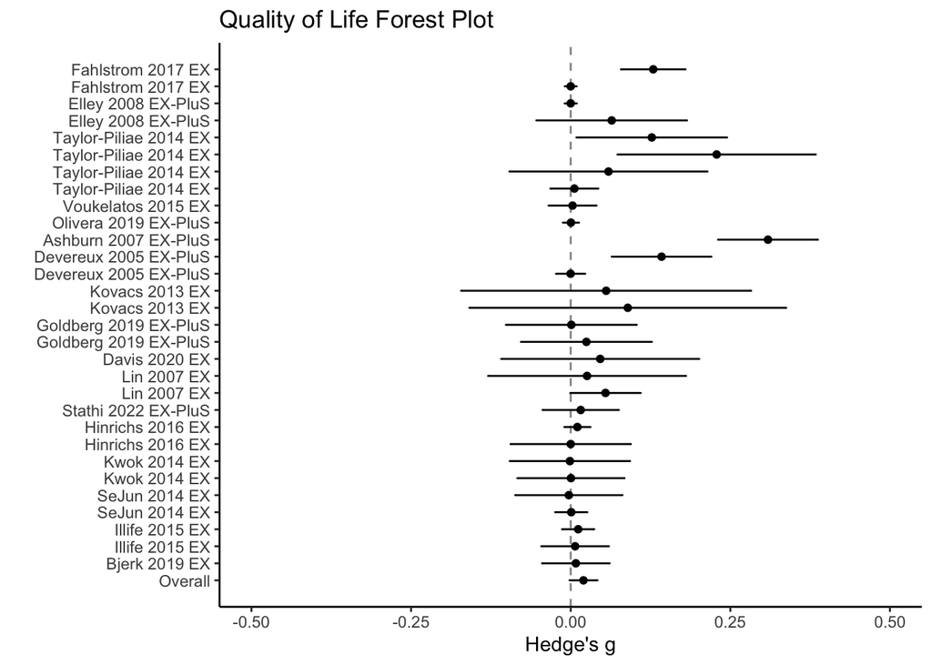

```r
QoL$Author_Year <- paste(QoL$Author, QoL$Year)
forest.QoL<-subset(QoL, select = c(Author_Year,Intervention_Type,QoL_hedge.g,QoL_g_LL95CI,
                                                   QoL_g_UL95CI))
forest.QoL$Effect_size<-c(2:31)
forest.QoL$Study_InterventionType<-paste(forest.QoL$Author_Year,forest.QoL$Intervention_Type)
forest.QoL$rev_ES<-rev(forest.QoL$Effect_size)
Overall.effect<-c("Overall", NA, 0.02, -0.00163, 0.0417, 1, "Overall", 1)
forest.QoL.plot<-rbind(forest.QoL, Overall.effect)
forest.QoL.plot$rev_ES<-as.numeric(forest.QoL.plot$Effect_size)
forest.QoL.plot$QoL_hedge.g<-as.numeric(forest.QoL.plot$QoL_hedge.g)
forest.QoL.plot$QoL_g_LL95CI<-as.numeric(forest.QoL.plot$QoL_g_LL95CI)
forest.QoL.plot$QoL_g_UL95CI<-as.numeric(forest.QoL.plot$QoL_g_UL95CI)

QoL.forest.plot<-ggplot(forest.QoL.plot, aes(y=rev_ES, x=QoL_hedge.g, xmin=QoL_g_LL95CI, xmax=QoL_g_UL95CI)) +
  geom_point() + geom_errorbarh(height=.1) + scale_y_continuous(name= "", breaks=rev(1:nrow(forest.QoL.plot)), labels=forest.QoL.plot$Study_InterventionType) +
  labs(title="Quality of Life Forest Plot", x="Hedge's g", y = "Author, Year, Intervention Type" ) + xlim(-0.5, 0.5) +
  geom_vline(xintercept=0, color="black", linetype="dashed", alpha=.5) + theme_classic()

QoL.forest.plot
```

# 4) Main Effects for Falls Risk

Incident Rate for Falls using Hedge’s g. Estimates are re-transformed by exponentiation

```r
falls.g<-robu(IRR_of_Falls_g~1, var=IRR_of_Falls_g_var, studynum=Study_ID, Falls)
print(falls.g)
```

```
## RVE: Correlated Effects Model with Small-Sample Corrections
##
## Model: IRR_of_Falls_g ~ 1
##
## Number of studies = 13
## Number of outcomes = 18 (min = 1 , mean = 1.38 , median = 1 , max = 2 )
## Rho = 0.8
## I.sq = 98.85916
## Tau.sq = 7.605732
##
##                Estimate StdErr t-value dfs P(|t|>) 95% CI.L 95% CI.U Sig
## 1 X.Intercept.    -3.03  0.722   -4.19  12 0.00126     -4.6    -1.45 ***
## ---
## Signif. codes: < .01 *** < .05 ** < .10 *
## ---
## Note: If df < 4, do not trust the results
```

```r
sensitivity(falls.g)
```

```
## RVE: Correlated Effects Model with Small-Sample Corrections
## Model: IRR_of_Falls_g ~ 1
##
## Sensitivity Analysis
##
##                           Rho = 0 Rho = 0.2 Rho = 0.4 Rho = 0.6 Rho = 0.8
##  X.Intercept. Coefficient -3.026  -3.026    -3.026    -3.026    -3.026
##               Std. Error   0.722   0.722     0.722     0.722     0.722
##  Tau.sq       Estimate     7.604   7.605     7.605     7.605     7.606
##  Rho = 1
##  -3.026
##   0.722
##   7.606
```

```r
irr.exp<-c(falls.g$reg_table$b.r, falls.g$reg_table$CI.L, falls.g$reg_table$CI.U)
exp(irr.exp) #Point Estimate, 95% CI LL, 95% CI UL
```

```
## [1] 0.04853266 0.01005825 0.23417781
```

Forest Plot for Incident Rate of Falls. Estimates are re-transformed by exponentiation

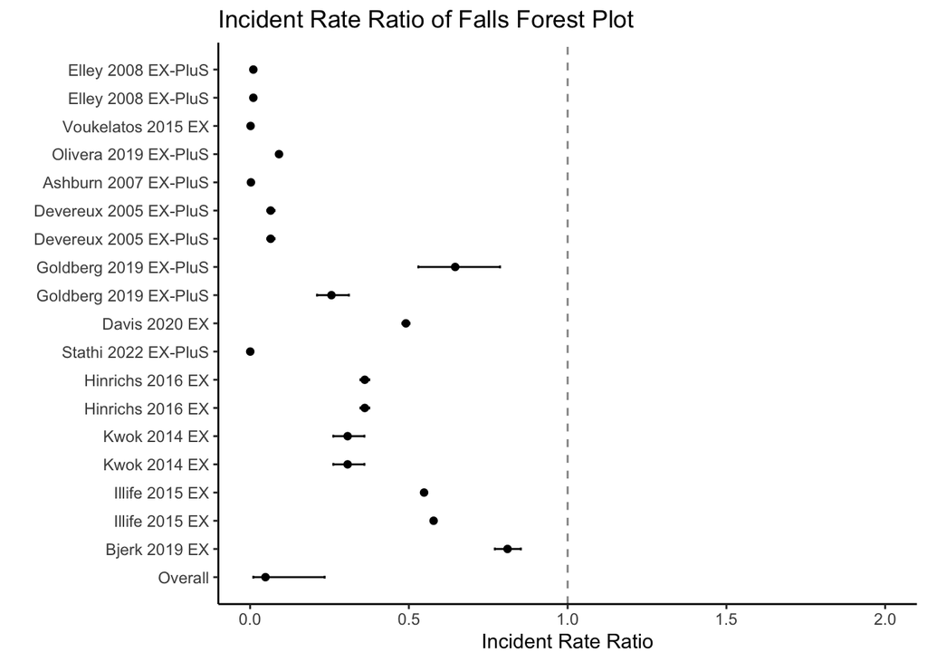

```r
Falls$Author_Year <- paste(Falls$Author, Falls$Year)
forest.IRRs<-subset(Falls, select = c(Author_Year,Intervention_Type,IRR_of_Falls_g,IRR_Falls_SMD_LL95CI,
                                          IRR_Falls_SMD_UL95CI))
forest.IRRs$Effect_size<-c(2:19)
forest.IRRs$Study_InterventionType<-paste(forest.IRRs$Author_Year,forest.IRRs$Intervention_Type)
forest.IRRs$rev_ES<-rev(forest.IRRs$Effect_size)
Overall.effect<-c("Overall", NA, -3.03, -4.60, -1.45, 1, "Overall", 1)
forest.IRRs.plot<-rbind(forest.IRRs, Overall.effect)
forest.IRRs.plot$rev_ES<-as.numeric(forest.IRRs.plot$rev_ES)
forest.IRRs.plot$IRR_of_Falls_g<-as.numeric(forest.IRRs.plot$IRR_of_Falls_g)
forest.IRRs.plot$IRR_Falls_SMD_LL95CI<-as.numeric(forest.IRRs.plot$IRR_Falls_SMD_LL95CI)
forest.IRRs.plot$IRR_Falls_SMD_UL95CI<-as.numeric(forest.IRRs.plot$IRR_Falls_SMD_UL95CI)
forest.IRRs.plot$IRR_exp<-exp(forest.IRRs.plot$IRR_of_Falls_g)
forest.IRRs.plot$UL_exp<-exp(forest.IRRs.plot$IRR_Falls_SMD_UL95CI)
forest.IRRs.plot$LL_exp<-exp(forest.IRRs.plot$IRR_Falls_SMD_LL95CI)

IRR.plot<-ggplot(forest.IRRs.plot, aes(y=rev_ES, x=IRR_exp, xmin=LL_exp, xmax=UL_exp)) +
  geom_point() + geom_errorbarh(height=.1) + scale_y_continuous(name= "", breaks=rev(1:nrow(forest.IRRs.plot)), labels=forest.IRRs.plot$Study_InterventionType) +
  labs(title="Incident Rate Ratio of Falls Forest Plot", x="Incident Rate Ratio", y = "Author, Year, Intervention Type" ) + xlim(0, 2) +
  geom_vline(xintercept=1, color="black", linetype="dashed", alpha=.5) + theme_classic()

IRR.plot
```

# 5) Does Intervention Type (EX vs. EX-Plus) moderate the effects on Quality of Life and Falls Risk

Quality of Life

```r
robu(QoL_hedge.g~Intervention_Type-1, var.eff.size = QoL_var.g, studynum = Study_ID, data = QoL)
```

```
## RVE: Correlated Effects Model with Small-Sample Corrections
##
## Model: QoL_hedge.g ~ Intervention_Type - 1
##
## Number of studies = 18
## Number of outcomes = 30 (min = 1 , mean = 1.67 , median = 2 , max = 4 )
## Rho = 0.8
## I.sq = 0
## Tau.sq = 0
##
##                            Estimate  StdErr t-value  dfs P(|t|>) 95% CI.L
## 1      Intervention_TypeEX   0.0256 0.01640    1.56 4.75   0.182  -0.0172
## 2 Intervention_TypeEX.PluS   0.0114 0.00731    1.55 3.28   0.210  -0.0108
##   95% CI.U Sig
## 1   0.0685
## 2   0.0335
## ---
## Signif. codes: < .01 *** < .05 ** < .10 *
## ---
## Note: If df < 4, do not trust the results
```

```r
QoL.mod<-robu(QoL_hedge.g~Intervention_Type-1, var.eff.size = QoL_var.g, studynum = Study_ID, data = QoL)
cpairs<- constraints<-matrix(c(1,-1), 1,2)
Wald_test(QoL.mod, constraints = cpairs, vcov = "CR2", tidy = TRUE)
```

```
##  test Fstat df_num df_denom p_val sig
##   HTZ 0.632      1     6.91 0.453
```

Incident Rate of Falls

```r
robu(IRR_of_Falls_g~Intervention_Type-1, var.eff.size = IRR_of_Falls_g_var, studynum = Study_ID, data = Falls)
```

```
## RVE: Correlated Effects Model with Small-Sample Corrections
##
## Model: IRR_of_Falls_g ~ Intervention_Type - 1
##
## Number of studies = 13
## Number of outcomes = 18 (min = 1 , mean = 1.38 , median = 1 , max = 2 )
## Rho = 0.8
## I.sq = 97.94645
## Tau.sq = 4.41076
##
##                            Estimate StdErr t-value  dfs P(|t|>) 95% CI.L
## 1      Intervention_TypeEX    -1.70  0.979   -1.74 5.00 0.14236    -4.22
## 2 Intervention_TypeEX.PluS    -4.19  0.877   -4.78 5.99 0.00307    -6.34
##   95% CI.U Sig
## 1    0.813
## 2   -2.047 ***
## ---
## Signif. codes: < .01 *** < .05 ** < .10 *
## ---
## Note: If df < 4, do not trust the results
```

```r
Falls.mod<-robu(IRR_of_Falls_g~Intervention_Type-1, var.eff.size = IRR_of_Falls_g_var, studynum = Study_ID, data = Falls)
cpairs<- constraints<-matrix(c(1,-1), 1,2)
Wald_test(Falls.mod, constraints = cpairs, vcov = "CR2", tidy = TRUE)
```

```
##  test Fstat df_num df_denom  p_val sig
##   HTZ  3.59      1     10.7 0.0855   .
```

```r
irr.exp<-c(Falls.mod$reg_table$b.r, Falls.mod$reg_table$CI.L, Falls.mod$reg_table$CI.U)
irr.exp
```

```
## [1] -1.7033740 -4.1926123 -4.2201266 -6.3384061  0.8133786 -2.0468186
```

```r
exp(irr.exp) #Point Estimate EX, Point Estimate EX-Plus, 95% CI LL EX, 95% CI LL EX-Plus, 95% CI UL EX, 95% CI UL EX-Plus
```

```
## [1] 0.182068187 0.015106769 0.014696783 0.001767117 2.255515619 0.129145118
```

# 6) Does Quality of Life measure (EQ5D, SF-36 Mental, or SF-36 Physical) moderate the effect size of Quality of Life?

```r
robu(QoL_hedge.g~QoL_Measure_Used-1, var.eff.size = QoL_var.g, studynum = Study_ID, data = QoL)
```

```
## RVE: Correlated Effects Model with Small-Sample Corrections
##
## Model: QoL_hedge.g ~ QoL_Measure_Used - 1
##
## Number of studies = 18
## Number of outcomes = 30 (min = 1 , mean = 1.67 , median = 2 , max = 4 )
## Rho = 0.8
## I.sq = 0
## Tau.sq = 0
##
##                                  Estimate  StdErr t-value  dfs P(|t|>) 95% CI.L
## 1           QoL_Measure_UsedEQ5D   0.0137 0.00993    1.38 4.01   0.239  -0.0138
## 2   QoL_Measure_UsedSF.36.Mental   0.0369 0.03080    1.20 3.52   0.305  -0.0535
## 3 QoL_Measure_UsedSF.36.Physical   0.0268 0.01410    1.90 3.52   0.140  -0.0146
##   95% CI.U Sig
## 1   0.0413
## 2   0.1273
## 3   0.0682
## ---
## Signif. codes: < .01 *** < .05 ** < .10 *
## ---
## Note: If df < 4, do not trust the results
```

```r
QoL.mod<-robu(QoL_hedge.g~QoL_Measure_Used-1, var.eff.size = QoL_var.g, studynum = Study_ID, data = QoL)
cpairs<- constraints<-matrix(c(1,0,-1), 1,3)
Wald_test(QoL.mod, constraints = cpairs, vcov = "CR2", tidy = TRUE)
```

```
##  test Fstat df_num df_denom p_val sig
##   HTZ 0.574      1     5.31 0.481
```

# 7) Funnel Plots for Publication Bias

Quality of Life

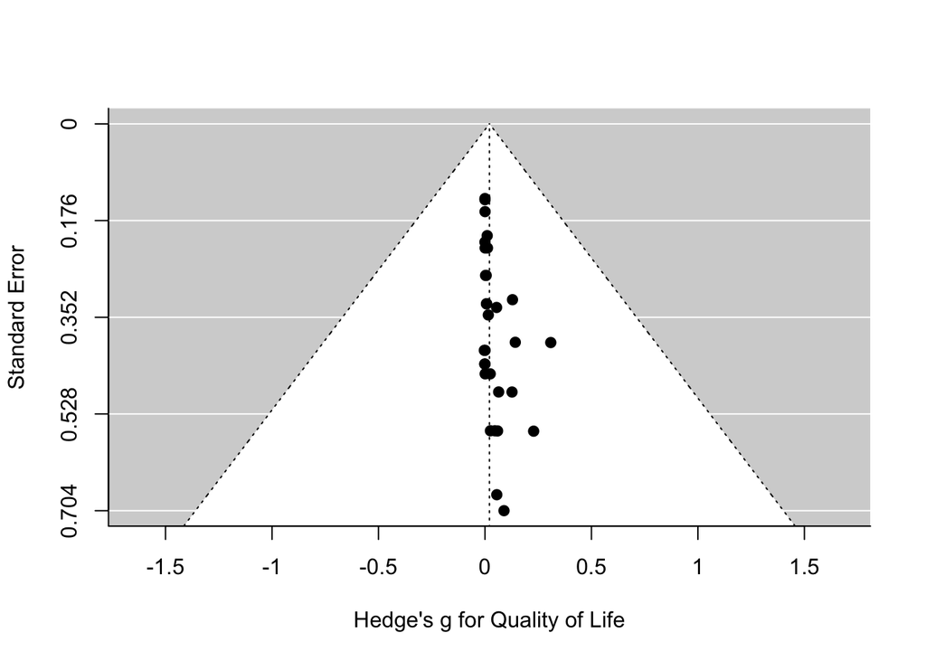

```r
meta.res.QoL<-rma.mv(yi=QoL_hedge.g,V=QoL_var.g,data=QoL,slab=Study_ID)
funnel(meta.res.QoL, xlab = "Hedge's g for Quality of Life")
```

Incident Rate of Falls

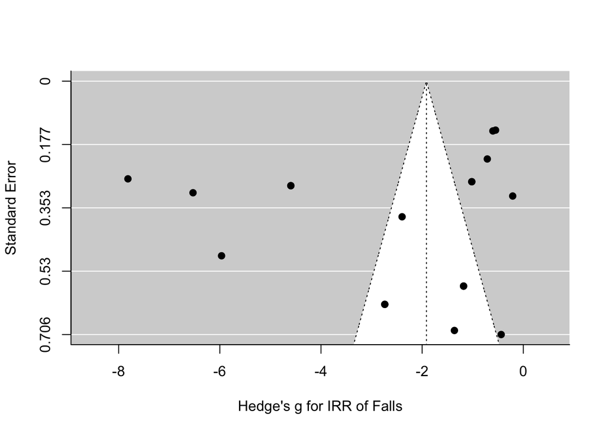

```r
meta.res.falls<-rma.mv(yi=IRR_of_Falls_g,V=IRR_of_Falls_g_var,data=Falls,slab=Study_ID)
funnel(meta.res.falls, xlab = "Hedge's g for IRR of Falls")
```

# 6) PEESE

Quality of Life

```r
QoL$sesqrd.ES<-QoL$QoL_se.g^2
peese.rve.costs <- robu(QoL_hedge.g~sesqrd.ES, var.eff.size = QoL_var.g, studynum = Study_ID, data = QoL)
print(peese.rve.costs)
```

```
## RVE: Correlated Effects Model with Small-Sample Corrections
##
## Model: QoL_hedge.g ~ sesqrd.ES
##
## Number of studies = 18
## Number of outcomes = 30 (min = 1 , mean = 1.67 , median = 2 , max = 4 )
## Rho = 0.8
## I.sq = 0
## Tau.sq = 0
##
##                Estimate  StdErr t-value  dfs P(|t|>)  95% CI.L 95% CI.U Sig
## 1 X.Intercept.   0.0132 0.00809    1.63 7.02   0.148  -0.00595   0.0323
## 2    sesqrd.ES  10.4318 6.24858    1.67 2.38   0.217 -12.72004  33.5836
## ---
## Signif. codes: < .01 *** < .05 ** < .10 *
## ---
## Note: If df < 4, do not trust the results
```

Incident Rate of Falls

```r
Falls$sesqrd.ES<-Falls$IRR_of_Falls_g_se^2
peese.rve.falls <- robu(IRR_of_Falls_g~sesqrd.ES, var.eff.size = IRR_of_Falls_g_var, studynum = Study_ID, data = Falls)
print(peese.rve.falls)
```

```
## RVE: Correlated Effects Model with Small-Sample Corrections
##
## Model: IRR_of_Falls_g ~ sesqrd.ES
##
## Number of studies = 13
## Number of outcomes = 18 (min = 1 , mean = 1.38 , median = 1 , max = 2 )
## Rho = 0.8
## I.sq = 98.94388
## Tau.sq = 7.893087
##
##                Estimate StdErr t-value  dfs P(|t|>) 95% CI.L 95% CI.U Sig
## 1 X.Intercept.    -3.51   0.95   -3.70 9.14  0.0048    -5.66    -1.37 ***
## 2    sesqrd.ES   222.63 134.55    1.65 2.80  0.2031  -223.56   668.82
## ---
## Signif. codes: < .01 *** < .05 ** < .10 *
## ---
## Note: If df < 4, do not trust the results
```

```r
peese.falls.exp<-c(peese.rve.falls$reg_table$b.r, peese.rve.falls$reg_table$CI.L, peese.rve.falls$reg_table$CI.U)
peese.falls.exp
```

```
## [1]   -3.512381  222.629297   -5.655931 -223.557102   -1.368831  668.815697
```

```r
exp(peese.falls.exp) #Point Estimate EX, Point Estimate EX-Plus, 95% CI LL EX, 95% CI LL EX-Plus, 95% CI UL EX, 95% CI UL EX-Plus
```

```
## [1]  2.982582e-02  4.860437e+96  3.496716e-03  8.135499e-98  2.544042e-01
## [6] 2.903799e+290
```

# 7) Egger’s Regression Test for Dependent Effect Sizes

Quality of Life

```r
pet.rve.cost<-robu(QoL_hedge.g~QoL_se.g, var.eff.size=QoL_var.g,
                   studynum=Study_ID, data=QoL)

print(pet.rve.cost)
```

```
## RVE: Correlated Effects Model with Small-Sample Corrections
##
## Model: QoL_hedge.g ~ QoL_se.g
##
## Number of studies = 18
## Number of outcomes = 30 (min = 1 , mean = 1.67 , median = 2 , max = 4 )
## Rho = 0.8
## I.sq = 0
## Tau.sq = 0
##
##                Estimate  StdErr t-value  dfs P(|t|>) 95% CI.L 95% CI.U Sig
## 1 X.Intercept. -0.00329 0.00561  -0.586 5.20  0.5825  -0.0175    0.011
## 2     QoL_se.g  1.31919 0.46065   2.864 6.53  0.0261   0.2140    2.424  **
## ---
## Signif. codes: < .01 *** < .05 ** < .10 *
## ---
## Note: If df < 4, do not trust the results
```

Incident Rate of Falls

```r
pet.rve.falls<-robu(IRR_of_Falls_g~IRR_of_Falls_g_se, var.eff.size=IRR_of_Falls_g_var,
                    studynum=Study_ID, data=Falls)

print(pet.rve.falls)
```

```
## RVE: Correlated Effects Model with Small-Sample Corrections
##
## Model: IRR_of_Falls_g ~ IRR_of_Falls_g_se
##
## Number of studies = 13
## Number of outcomes = 18 (min = 1 , mean = 1.38 , median = 1 , max = 2 )
## Rho = 0.8
## I.sq = 98.93817
## Tau.sq = 8.232375
##
##                     Estimate StdErr t-value  dfs P(|t|>) 95% CI.L 95% CI.U Sig
## 1      X.Intercept.    -3.78   1.21   -3.12 8.86  0.0126    -6.52    -1.03  **
## 2 IRR_of_Falls_g_se    21.39  17.15    1.25 3.71  0.2853   -27.76    70.55
## ---
## Signif. codes: < .01 *** < .05 ** < .10 *
## ---
## Note: If df < 4, do not trust the results
```

```r
eggers.falls.exp<-c(pet.rve.falls$reg_table$b.r, pet.rve.falls$reg_table$CI.L, pet.rve.falls$reg_table$CI.U)
eggers.falls.exp
```

```
## [1]  -3.776496  21.394219  -6.521944 -27.757754  -1.031048  70.546192
```

```r
exp(eggers.falls.exp) #Point Estimate EX, Point Estimate EX-Plus, 95% CI LL EX, 95% CI LL EX-Plus, 95% CI UL EX, 95% CI UL EX-Plus
```

```
## [1] 2.290280e-02 1.956101e+09 1.470806e-03 8.809685e-13 3.566332e-01
## [6] 4.343322e+30
```

# 8) Leave-One-Out Analyses

Quality of Life

```r
leave.one.out.all<- function(rownum){

  # subset dataframe
  vec <- rep(TRUE, nrow(QoL))
  vec[rownum] <- FALSE
  inf <- subset(QoL, vec)

  # fit reference model
  rve.model.ref <- robu(QoL_hedge.g~1,var=QoL_var.g,studynum=Study_ID, QoL)

  # fit adjusted model
  rve.model <- robu(QoL_hedge.g~1,var=QoL_var.g,studynum=Study_ID, data = inf)

  # return results
  results.vec <- c(ES.study = round(QoL$QoL_hedge.g[rownum], 3),
                   ES.adj = round(rve.model$reg_table$b.r, 3),
                   se.ES.adj = round(rve.model$reg_table$SE, 3),
                   p.adj = round(rve.model$reg_table$prob, 5),
                   diff.ES = round(rve.model$reg_table$b.r - rve.model.ref$reg_table$b.r, 3),
                   diff.se.ES = round(rve.model$reg_table$SE - rve.model.ref$reg_table$SE, 3),
                   diff.p = round(rve.model$reg_table$prob - rve.model.ref$reg_table$prob, 5),
                   diff.isq = round(rve.model$mod_info$I.2 - rve.model.ref$mod_info$I.2, 3))
  return(results.vec)
}

inf.all <- sapply(1:nrow(QoL), leave.one.out.all)
inf.all <- data.frame(t(inf.all))
inf.all <- data.frame(label = paste(QoL$Study_ID, QoL$Intervention_Type, sep = " / "),
                      inf.all)
inf.all$z.ES.study <- round(scale(inf.all$ES.study), 2)

inf.all
```

```
##           label ES.study ES.adj se.ES.adj   p.adj diff.ES diff.se.ES   diff.p
## 1        1 / EX    0.008  0.020     0.010 0.06608   0.000      0.000  0.00017
## 2        1 / EX    0.007  0.020     0.010 0.06574   0.000      0.000 -0.00017
## 3   2 / EX-PluS    0.012  0.021     0.010 0.08433   0.001      0.001  0.01842
## 4   3 / EX-PluS    0.001  0.022     0.011 0.07551   0.002      0.001  0.00960
## 5        4 / EX   -0.003  0.020     0.010 0.06585   0.000      0.000 -0.00006
## 6        4 / EX    0.000  0.020     0.010 0.06603   0.000      0.000  0.00013
## 7        4 / EX   -0.001  0.020     0.010 0.06584   0.000      0.000 -0.00007
## 8        4 / EX    0.000  0.020     0.010 0.06591   0.000      0.000  0.00000
## 9        5 / EX    0.010  0.021     0.011 0.08696   0.001      0.001  0.02105
## 10  6 / EX-PluS    0.016  0.020     0.010 0.07488   0.000      0.000  0.00898
## 11  7 / EX-PluS    0.055  0.019     0.010 0.08465  -0.001      0.000  0.01874
## 12  8 / EX-PluS    0.026  0.020     0.010 0.06513   0.000      0.000 -0.00078
## 13  8 / EX-PluS    0.046  0.020     0.009 0.06675   0.000      0.000  0.00084
## 14       9 / EX    0.025  0.020     0.009 0.06759   0.000      0.000  0.00168
```

[output cut: 47 more lines]

Incident Rate of Falls

```r
leave.one.out.all.falls<- function(rownum){

  # subset dataframe
  vec <- rep(TRUE, nrow(Falls))
  vec[rownum] <- FALSE
  inf <- subset(Falls, vec)

  # fit reference model
  rve.model.ref <- robu(IRR_of_Falls_g~1,var=IRR_of_Falls_g_var,studynum=Study_ID, Falls)

  # fit adjusted model
  rve.model <- robu(IRR_of_Falls_g~1,var=IRR_of_Falls_g_var,studynum=Study_ID, data = inf)

  # return results
  results.vec <- c(ES.study = round(Falls$IRR_of_Falls_g[rownum], 3),
                   ES.adj = round(rve.model$reg_table$b.r, 3),
                   se.ES.adj = round(rve.model$reg_table$SE, 3),
                   p.adj = round(rve.model$reg_table$prob, 5),
                   diff.ES = round(rve.model$reg_table$b.r - rve.model.ref$reg_table$b.r, 3),
                   diff.se.ES = round(rve.model$reg_table$SE - rve.model.ref$reg_table$SE, 3),
                   diff.p = round(rve.model$reg_table$prob - rve.model.ref$reg_table$prob, 5),
                   diff.isq = round(rve.model$mod_info$I.2 - rve.model.ref$mod_info$I.2, 3))
  return(results.vec)
}

inf.all <- sapply(1:nrow(Falls), leave.one.out.all.falls)
inf.all <- data.frame(t(inf.all))
inf.all <- data.frame(label = paste(Falls$Study_ID, Falls$Intervention_Type, sep = " / "),
                      inf.all)
inf.all$z.ES.study <- round(scale(inf.all$ES.study), 2)

inf.all
```

```
##           label ES.study ES.adj se.ES.adj   p.adj diff.ES diff.se.ES   diff.p
## 1   2 / EX-PluS   -4.596 -2.893     0.773 0.00324   0.133      0.050  0.00198
## 2   3 / EX-PluS   -4.596 -2.893     0.773 0.00324   0.133      0.050  0.00198
## 3        5 / EX   -6.530 -2.731     0.718 0.00293   0.294     -0.004  0.00167
## 4   6 / EX-PluS   -2.397 -3.078     0.783 0.00235  -0.052      0.061  0.00109
## 5   7 / EX-PluS   -5.966 -2.783     0.739 0.00314   0.242      0.017  0.00188
## 6   8 / EX-PluS   -2.739 -3.026     0.722 0.00126   0.000      0.000  0.00000
## 7   8 / EX-PluS   -2.739 -3.026     0.722 0.00126   0.000      0.000  0.00000
## 8  10 / EX-PluS   -0.437 -3.060     0.715 0.00107  -0.034     -0.007 -0.00019
## 9  10 / EX-PluS   -1.362 -2.992     0.731 0.00150   0.034      0.009  0.00024
## 10      11 / EX   -0.712 -3.220     0.756 0.00135  -0.195      0.034  0.00009
## 11 13 / EX-PluS   -7.817 -2.622     0.653 0.00203   0.403     -0.069  0.00078
## 12      14 / EX   -1.019 -3.026     0.722 0.00126   0.000      0.000  0.00000
## 13      14 / EX   -1.019 -3.026     0.722 0.00126   0.000      0.000  0.00000
## 14      15 / EX   -1.181 -3.026     0.722 0.00126   0.000      0.000  0.00000
```

[output cut: 23 more lines]